# Consequências Oriundas da Pandemia da Covid-19 nos Estudantes Universitários Brasileiros

Uma Análise Exploratória

Henrique Campos Mercez dos Santos

Lívia Inglesis Barcellos

Marcelo José dos Santos

Shelley Navari Christianini

João Pedro Albino

Universidade Estadual Paulista Júlio de Mesquita Filho - UNESP/Bauru

15 mar. 2023

Abstract

Em março de 2020, a Organização Mundial de Saúde (ONU) declarou oficialmente como pandemia a Covid-19. No Brasil, foi confirmado o primeiro caso do vírus em fevereiro de 2020, tendo posteriormente o número de contaminados e de óbitos se multiplicado rapidamente. No auge da pandemia, foi aplicada a quarentena rígida o que restringiu a circulação de pessoas e obrigou o fechamento de comércios e serviços considerados não essenciais. O país sofreu com a ausência de um plano efetivo na coordenação e distribuição de vacinas com desequilíbrios regionais e problemas de logística. O fechamento das universidades e a mudança repentina para o ensino remoto acarretou a queda do desempenho acadêmico e do bem-estar emocional de estudantes, funcionários e professores. O objetivo deste artigo é o de lançar alguma luz neste campo através da coleta e análise exploratória de dados sobre a COVID-19, visando compreender como a pandemia afetou os estudantes universitários.

## Introdução

Em março de 2020, a Organização Mundial de Saúde (ONU) declarou oficialmente como pandemia a Covid-19 (UNA-SUS, 2020), doença infecciosa causada pelo vírus SARS-CoV-2, detetada pela primeira vez em dezembro de 2019, na China. No Brasil, foi confirmado o primeiro caso do vírus em fevereiro de 2020, tendo posteriormente o número de contaminados e de óbitos se multiplicado rapidamente.  
Medidas de prevenção foram implementadas em todas as regiões do país para coibir a disseminação do vírus, tendo em vista a necessidade de preparar as unidades de pronto atendimento (UPA) e hospitais para receberem pacientes em larga escala em um curto período, uma vez que a contaminação entre os seres humanos pelo vírus SARS-CoV-2 é considerada alta (GUSSO et al, 2020).  
No Brasil, a primeira vacina a ser utilizada foi a CoronaVac, desenvolvida pelo Instituto Butantã em parceria com a fabricante chinesa de medicamentos Sinovac Biontech. A vacinação da população iniciou-se em janeiro de 2021. Desde então, 80,3% da população já completou o calendário vacinal (UOL, 2023) com todas as doses recomendadas, porém, órgãos de saúde pública e privada ainda trabalham para que a cobertura vacinal seja ainda maior, tendo em vista que a vacina deve ser reforçada, em média, a cada 4 meses. O impacto global da Covid-19 afetou diversos setores tais como saúde, política, economia e educação (The World Bank, 2023).  
Considerando-se os fatores causados pela COVID-19, a proposta desta pesquisa exploratória-descritiva é compreender como os estudantes universitários vivenciaram e vivenciam os efeitos da pandemia. Buscou-se investigar também de que forma se comportaram frente às restrições impostas pelos riscos de contágio, quais suas considerações a respeito das estratégias que foram adotadas pelas instituições de ensino superior, e como estes fatores influenciaram suas vidas.

## Impactos da Pandemia da COVID-19

A COVID-19 é uma síndrome respiratória aguda grave (SRAG) infecciosa causada pelo coronavírus, cujo agente etiológico é o SARS-CoV-2. Sua particularidade está na rapidez com que se manifesta entre seres humanos, levando a alta contaminação e elevação do número de casos (CAMPOS, MÔNICA RODRIGUES et al. 2020). Inicialmente, os sintomas mais comuns são febre, tosse seca, perda dos sentidos, olfato e paladar, e, em casos mais moderados/graves, falta de ar. Contudo, a doença apresenta manifestações diferentes a depender do indivíduo. Desde então, várias mutações surgiram em diferentes partes do mundo, algumas, inclusive, associadas a uma maior transmissibilidade e virulência.  
Por isso, medidas de proteção como usar máscaras e higienizar as mãos com sabão e álcool em gel, evitar aglomerações e manter o distanciamento social, além de completar o esquema vacinal contra a Covid-19, são iniciativas que funcionam contra todas as variantes da Covid-19. (BUTANTAN, 2021).

Além disso, as medidas preventivas incluíram, inicialmente, o isolamento social, quando as autoridades recomendaram que a população permanecesse em casa, evitando assim aglomerações e, consequentemente, a transmissão do vírus. Nesse período, os estados e municípios adotaram diferentes medidas de isolamento social, com diferentes níveis de restrição dado o número de infectados (MORAES, 2020). No auge da pandemia, antes da criação de uma vacina, foi aplicado o Lockdown (ou quarentena rígida) em determinadas localidades por um determinado período, restringindo a circulação de pessoas e a determinando o fechamento de comércios e serviços considerados não essenciais. Por último, seguiu-se a vacinação, com uma campanha conduzida de forma descentralizada, com cada Estado e município sendo responsáveis por adquirir e distribuir as vacinas (VEJA, 2022). Além de tais medidas, foram adotadas outras medidas adicionais de acordo com a situação local, tais como fechamento de escolas, restrições de circulação noturna, dentre outras.  
As principais críticas às decisões tomadas pelos governos, tanto na esfera federal, estadual ou municipal do Brasil, se deram pela falta de planejamento. O país sofreu com a ausência de um plano efetivo na coordenação e distribuição de vacinas, tendo dificuldades principalmente quanto ao abastecimento, com desequilíbrios regionais e problemas de logística. A falta de apoio econômico e social para as pessoas afetadas pela pandemia também foi um fator de grande impacto, pois muitos foram afetados economicamente pela pandemia e pela necessidade de isolamento social (CEPAL, 2021). A falta de transparência e de informações precisas sobre a pandemia, da real situação nacional e de como as medidas governamentais foram adotadas, foram muito criticadas, assim como a falta de dados consistentes e atualizados (World Health Organization, 2020).  
A demora na compra das vacinas, impedindo a eficaz imunização no país, é uma das principais causas da política de negacionismo, onde governadores e líderes políticos minimizaram a gravidade da pandemia (O Globo, 2021) e se recusaram a adotar medidas recomendadas pelas autoridades de saúde mundiais, fator extremamente criticado por especialistas (FIOCRUZ,2021), pois levou a uma disseminação descontrolada do vírus e a consequente sobrecarga nos sistemas de saúde durante o pico do contágio da COVID-19.  
A pandemia da COVID-19 teve um grande impacto na vida dos estudantes de nível superior no Brasil, de acordo com estudo realizado em 2020 pela Associação Nacional dos Dirigentes das Instituições Federais de Ensino Superior (ANDIFES, 2020).  
Com as medidas de distanciamento social e a suspensão de atividades presenciais nas universidades, muitos estudantes tiveram que lidar com desafios significativos em relação à continuidade dos estudos e à adaptação às novas formas de aprendizado. O impacto financeiro também foi um fator significativo para muitos estudantes de nível superior no Brasil. A pandemia afetou a economia do país, aumentando o desemprego e a insegurança financeira, o que levou muitos estudantes a enfrentarem dificuldades para pagar suas despesas básicas e para continuar seus estudos (ANDIFES, 2020).  
Portando, de acordo com De Negri (2020), pesquisadores e cientistas, no mundo todo, em muitos casos em um esforço concentrado envolvendo academia, governos e a iniciativa privada, se mobilizaram para estimar tanto os efeitos da doença sobre a saúde da população quanto os impactos econômicos e sociais dessa pandemia. Assim, afirmam os autores, pesquisas e projetos que busquem descrever e detalhar informações críticas sobre a pandemia e suas consequências imediatas serão sempre necessários.  
Nesta linha de pensamento, a proposta deste trabalho é o de lançar alguma luz neste campo e coletar dados exploratórios sobre a COVID-19, visando compreender como a pandemia afetou os estudantes universitários e de que forma se comportaram frente a esta nova realidade que está impactando fortemente suas vidas.

## Metodologia

O estudo apresentado neste artigo buscou compreender as influências da COVID-19 nos estudantes de ensino superior.  
Para atingir tal objetivo foi utilizada uma amostra de característica não probabilística e por conveniência. Os indivíduos empregados nessa pesquisa foram selecionados porque estavam voluntariamente disponíveis, e não foram selecionados por meio de um critério estatístico. A amostra, portanto, compreende alunos de diferentes níveis universitários (graduação e pós-graduação lato sensu e stricto sensu) matriculados nos diferentes períodos de sua formação (iniciantes e veteranos).  
Levou-se em consideração uma abordagem quali-quantitativa, por envolver aspectos opinativos e informações com o intuito de identificar as principais dificuldades enfrentadas. Tal abordagem foi escolhida dada a coleta de dados, realizada através de uma *survey*, e com a corroboração de outras fontes de informação para a análise, a fim de enriquecer a pesquisa realizada.

Toda a ciência é qualitativa, no sentido que pretende estabelecer uma qualidade a um objeto de estudo ao reproduzi-lo ou reconstruí-lo, ao explicá-lo ou compreendê-lo. A quantidade em si mesma nada representa se não se relaciona com determinada qualidade; as cifras e os dados não falam sozinhos, requerem uma interpretação que alude a uma teoria, à afirmação ou à negação de uma ideia. (…) técnicas quantitativas de levantamentos (surveys) que serão processados estatisticamente ou com histórias de vida que serão analisadas qualitativamente (BRICEÑO-LÉON, 2003).

Na intenção de identificar as principais dificuldades pelas instituições de ensino superior, foi adotado como instrumento de coleta de dados o uso de um questionário online auto aplicado utilizando o GoogleFormulários®, com perguntas fechadas e perguntas abertas, caracterizando-se, portanto, como uma pesquisa do tipo survey exploratória-descritiva.  
Do ponto de vista da ciência de dados, o objetivo foi o de extrair conhecimento e insights a partir dos dados disponíveis sobre a COVID-19 na população universitária brasileira. Através da análise exploratória desses dados (AED), foi possível identificar padrões e tendências relacionadas à disseminação da doença entre os estudantes da amostra obtida, bem como explorar as possíveis consequências dessa disseminação, como o impacto no ensino e nas atividades acadêmicas.  
Além disso, a ciência de dados pode ser usada para desenvolver modelos preditivos que possam ajudar a prever a propagação da COVID-19 nas universidades brasileiras e fornecer informações valiosas para apoiar as decisões tomadas pelos gestores das universidades, políticos e profissionais de saúde.  
É importante ressaltar que a análise de dados em relação à COVID-19 na população universitária foi realizada com todo o cuidado e atenção, levando em consideração questões éticas e de privacidade dos indivíduos envolvidos, sendo a pesquisa aprovada pelo conselho de ética da UNESP e registrada na Plataforma Brasil sob o CAAE: 47289921.9.0000.5663.  
Este artigo apresenta o relatório da análise exploratória de dados sobre como a pandemia de Coronavírus (Covid-19) afetou a vida e cotidiano dos estudantes universitários. O questionário ficou disponível de abril de 2021 a dezembro de 2022, contendo 50 questões.  
COmo pode ser observado na figura do Gráfico 1, a pesquisa contou com a participação de 52 integrantes, sendo que 48% se declaram do gênero masculino, 46% feminino, 4% transgênero/transexual e 2% homem gay. A amostra foi composta ainda por 77% de alunos da UNESP e 23% de demais instituições.

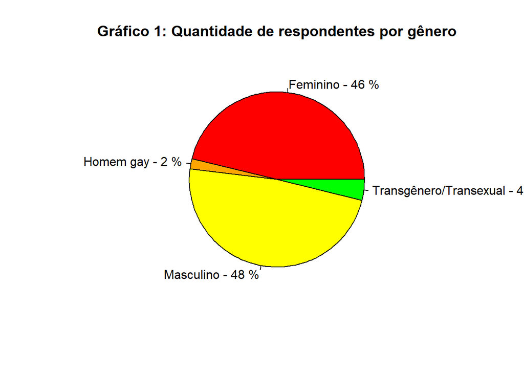

## Análise Exploratória de Dados

A Análise Exploratória de Dados (AED), de acordo com James et al. (2013), é uma abordagem de análise de dados que se concentra em compreender e resumir as principais características dos dados por meio de técnicas estatísticas e gráficas. O principal objetivo da AED é descobrir padrões, tendências, anomalias e relações entre as variáveis em um conjunto de dados, com o objetivo de gerar hipóteses e insights para análises mais aprofundadas, afirmam os autores.  
De acordo com Tukey (1977), o processo de AED envolve a “coleta de dados, organização, sumarização, análise exploratória, modelagem e comunicação dos resultados”. A AED pode ser realizada tanto em conjuntos de dados pequenos quanto grandes e complexos, e pode ser aplicada em diversas áreas, como ciências sociais, biologia, economia, engenharia, entre outras.

## Perfil dos entrevistados

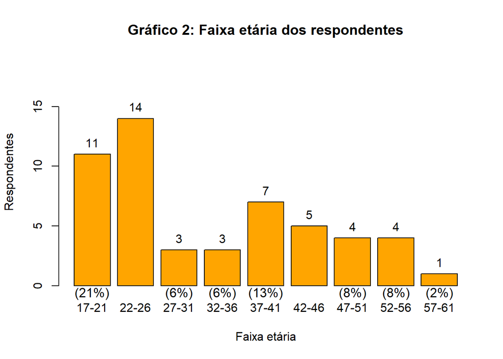

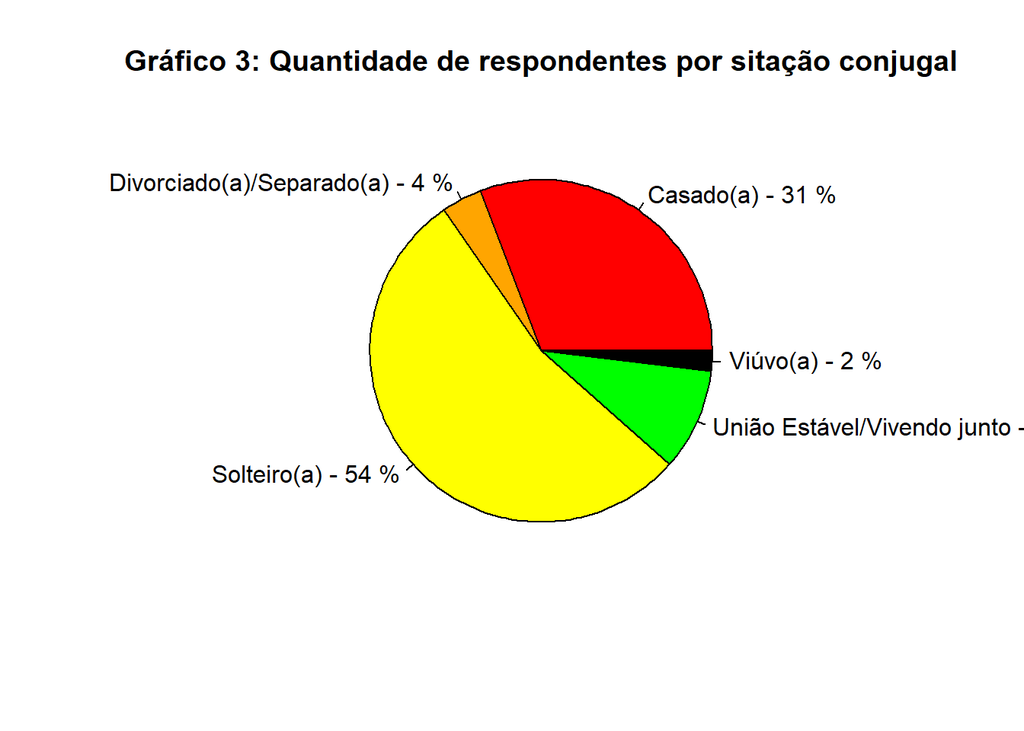

Ainda caracterizando o perfil dos entrevistados, na figura do Gráfico 4 foi apontado que o nível de escolaridade predominante da amostra é a graduação, com 21 respondentes (40%), seguido pelo doutorado com 15 (29%) e mestrado com 13 respondentes.

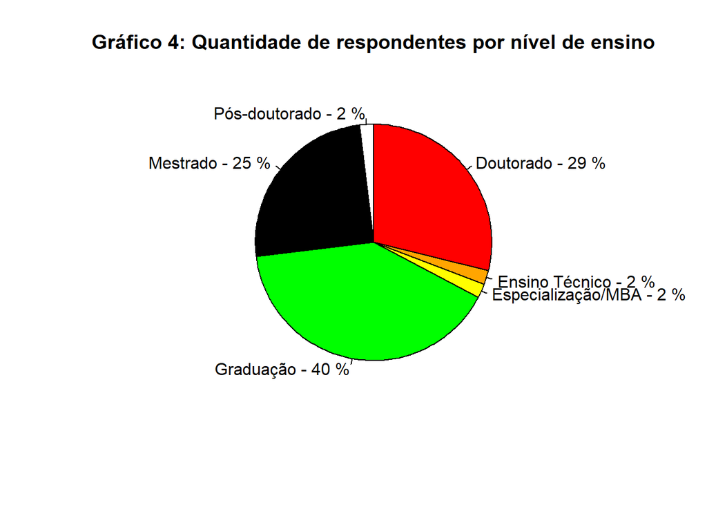

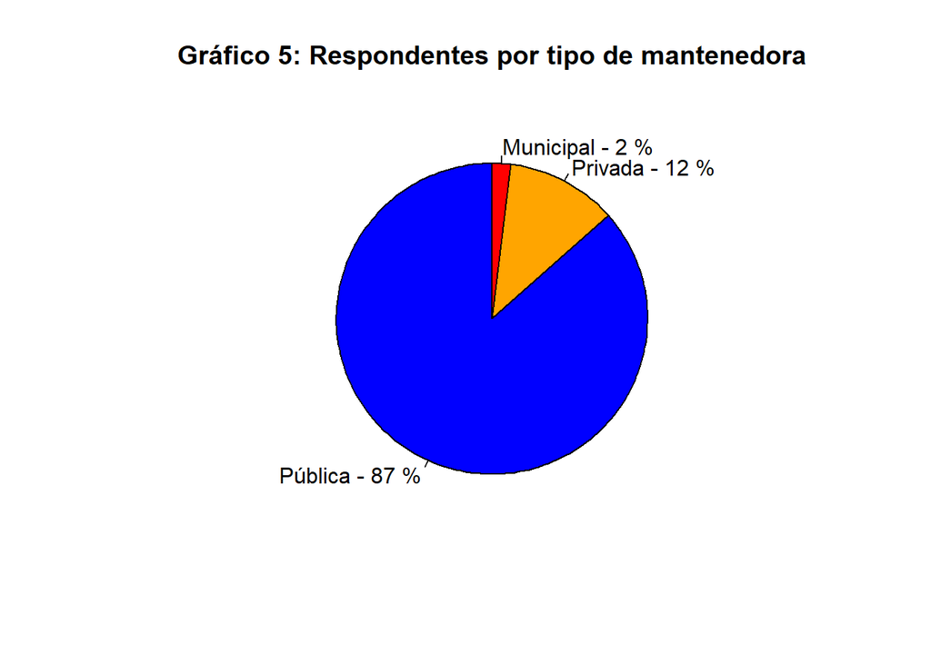

Ao analisar as condições financeiras dos participantes por meio do Gráfico 6, foi possível identificar que, do total de participantes da amostra, 56% estavam empregados, em diversos segmentos, 23% eram bolsistas ou estagiários, 13% eram dependentes e contavam com ajuda dos pais, 2% aposentados e 4% estavam desempregados.

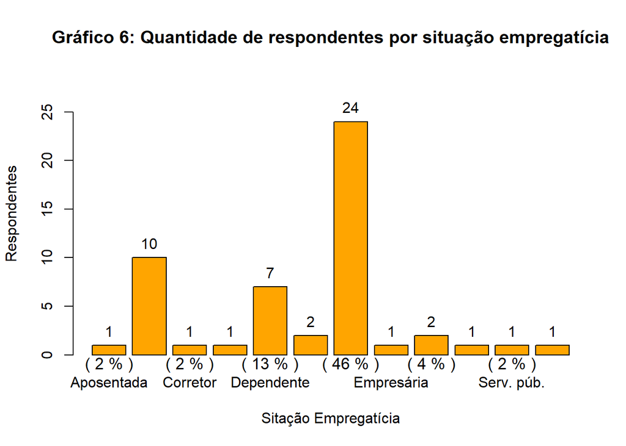

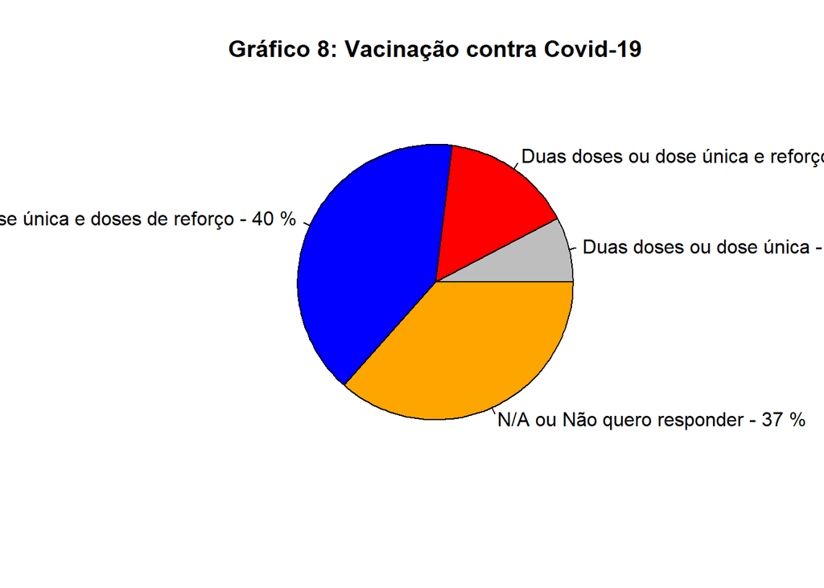

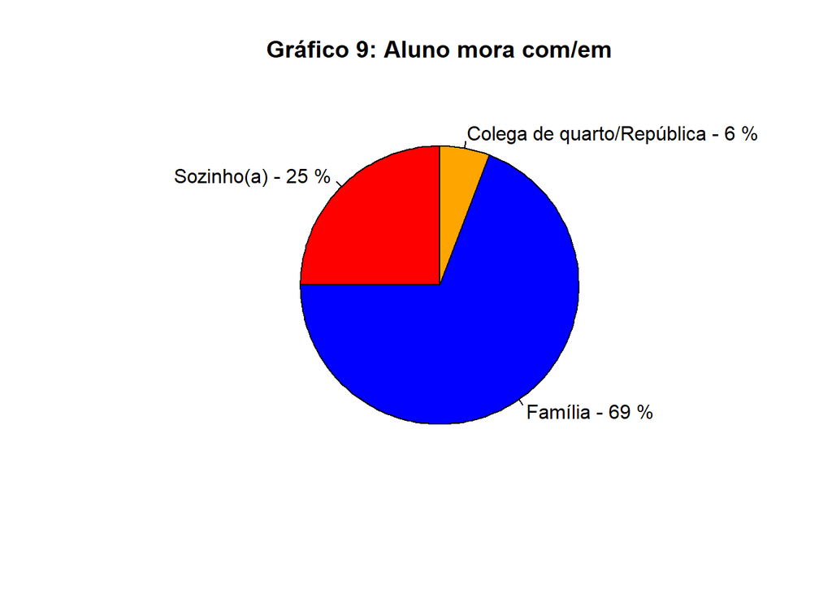

Conforme demonstrado no Gráfico 9, dos respondentes, 69% moravam com a família, seguido de 25% morando sozinho e, em último ficaram os que residiam em república ou com colega de quarto (6%).

## Decisões tomadas, acesso à infraestrutura e aos docentes

Sobre a decisão de fechar o campus para evitar a circulação de pessoas e, consequentemente, evitar a circulação do vírus, como pode ser observado na figura do Gráfico 10, 77% dos pesquisados consideram a decisão tomada em momento oportuno, enquanto 13% consideram lenta a demora para a tomada de decisão e 10% definem como muito rápido.

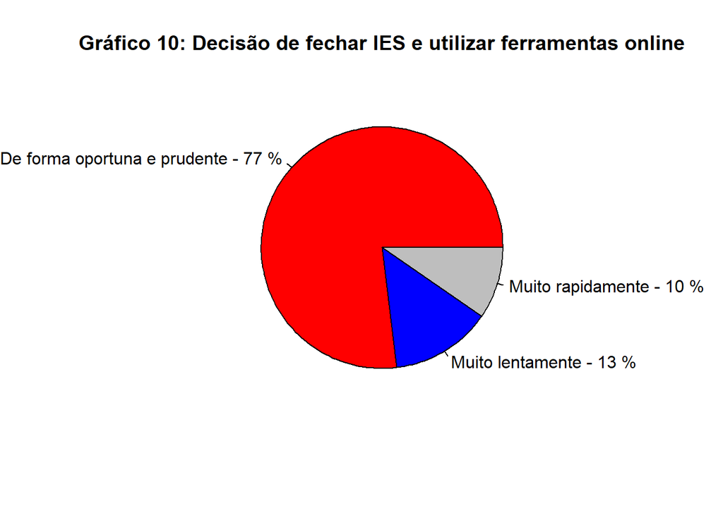

No que diz respeito à investigação se a Instituição de Nível Superior (IES) durante a pandemia transferiu todas suas atividades presenciais para o ensino remoto, apenas 2% dos alunos da amostra informaram que sua instituição não havia migrado para as aulas virtuais durante a pandemia, entretanto, 98% das IES da amostra se adaptaram de alguma forma para educação remota, como mostra o Grafico 11.

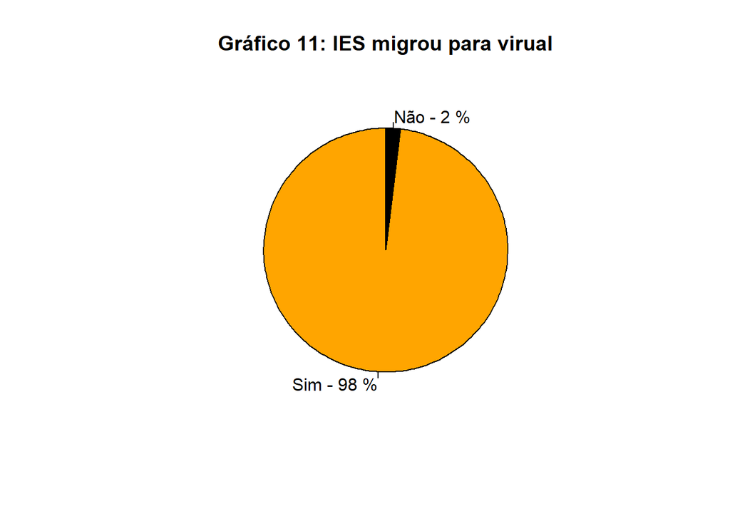

Já no tocante as formas de acesso aos recursos de infraestrutura oferecidos pela instituição (biblioteca, coordenação, orientação de assuntos acadêmicos, matrícula etc.) o Gráfico 12 mostra que, na opinião de 40% dos estudantes, o acesso aos recursos da IES pioraram durante a pandemia do COVID-19. Já 33% alegam que não houve mudanças.

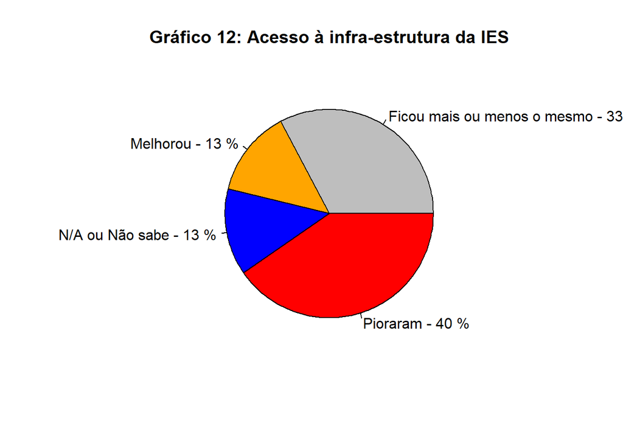

Os dados no Gráfico 12 indicam ainda que houve empate entre aqueles que alegam que houve melhorias e os que não sabem responder, ambos os lados representado 13% da amostra.

Ao abordar o acesso ao corpo docente das IES durante a pandemia (Gráfico 13), a maioria dos respondentes sentiu que o acesso aos professores foi pior (52%) que antes da pandemia, seguido por aqueles que acharam que não houve grandes dificuldades de comunicação (25%). Para uma parcela menor (15%) a disponibilidade dos docentes melhorou e apenas 8% não souberam responder.

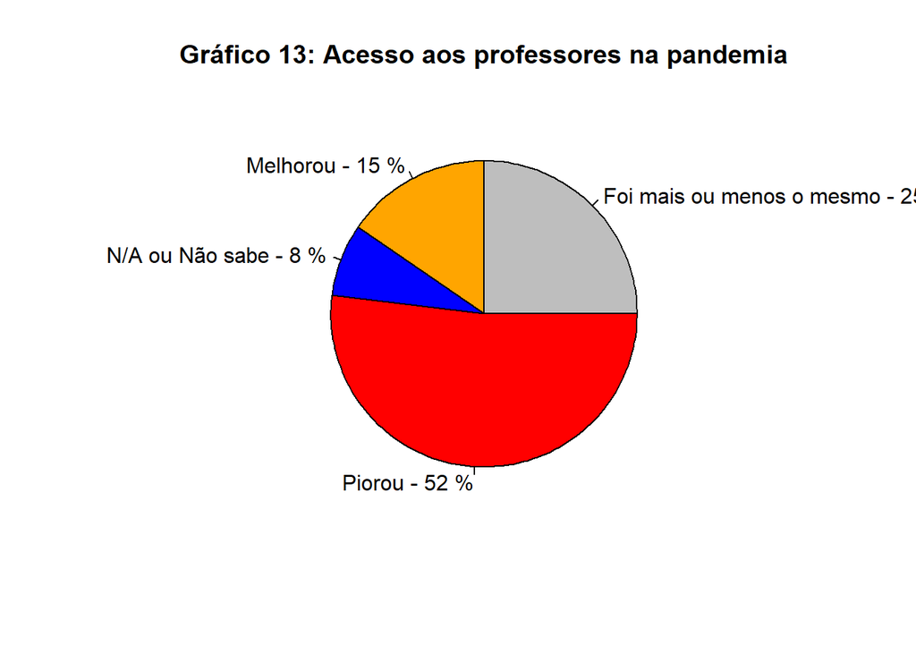

Quando questionados sobre a forma como as aulas foram ministradas durante a pandemia, de acordo com figura do Gráfico 14, 48% dos participantes não sentiram nenhuma alteração. Entretanto, 42% afirmaram que as aulas ministradas no estilo remoto foram piores que pelo método presencial, 8% não souberam dizer e apenas 2% acharam que o ensino remoto foi melhor.

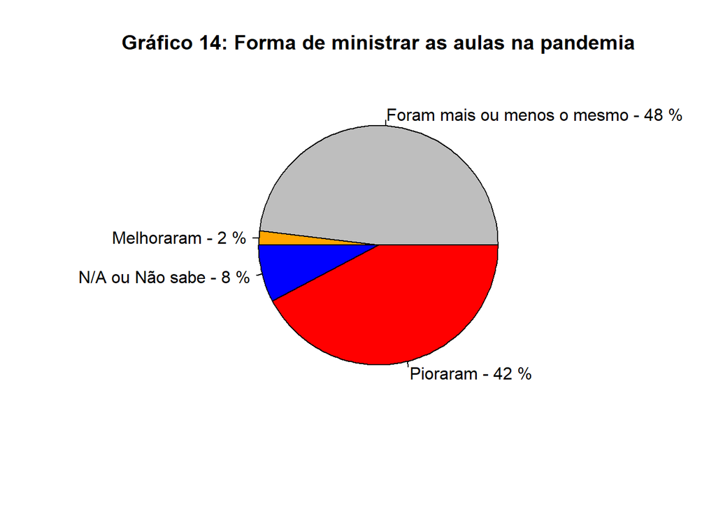

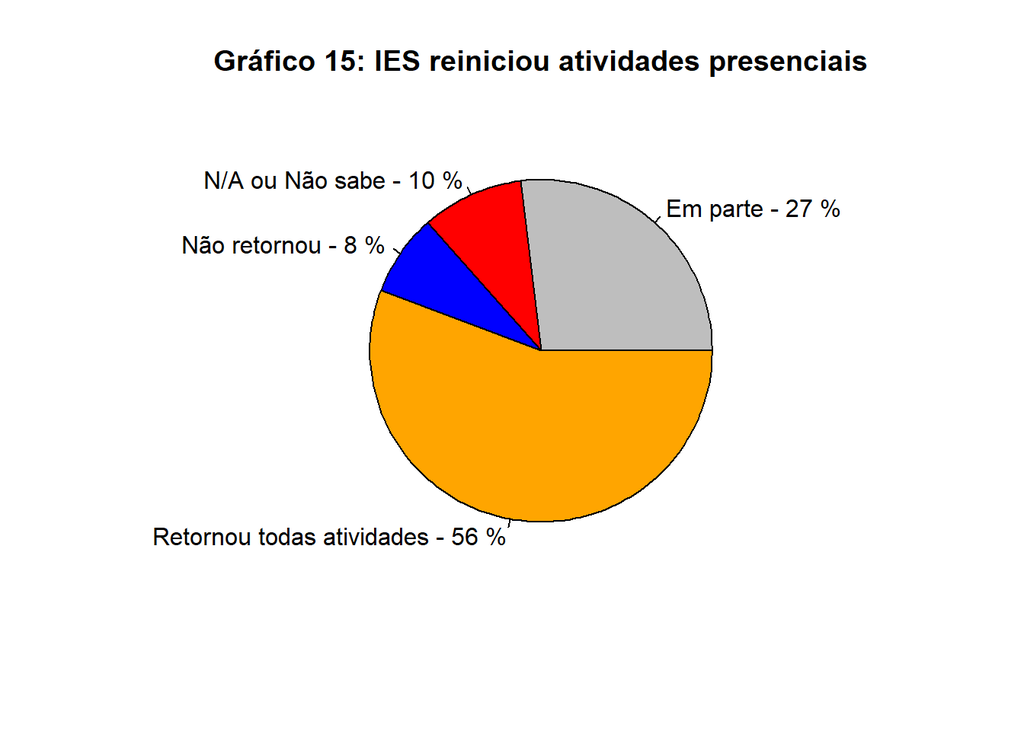

## Dificuldades enfrentadas pelos alunos

Buscando compreender as principais dificuldades individuais que os alunos de ensino superior enfrentaram durante a pandemia, um conjunto de questões foram elaboradas no questionário para coletar informações sobre esforços que os estudantes tiveram que enfrentar para cursar as disciplinas remotamente.  
Partindo da necessidade em utilizar a internet para as aulas, os alunos foram questionados quanto à qualidade do serviço de acesso à internet que tiveram que utilizar, comparando a antes e durante a pandemia da Covid-19.  
De acordo com o Gráfico 16, 65% dos respondentes afirmaram que não houve nenhuma mudança, para 13% o acesso aos serviços de internet piorou e 19% sentiram que houve melhora. Apenas 2% não souberam responder. De modo geral, para os estudantes pesquisados o acesso a internet não mudou.

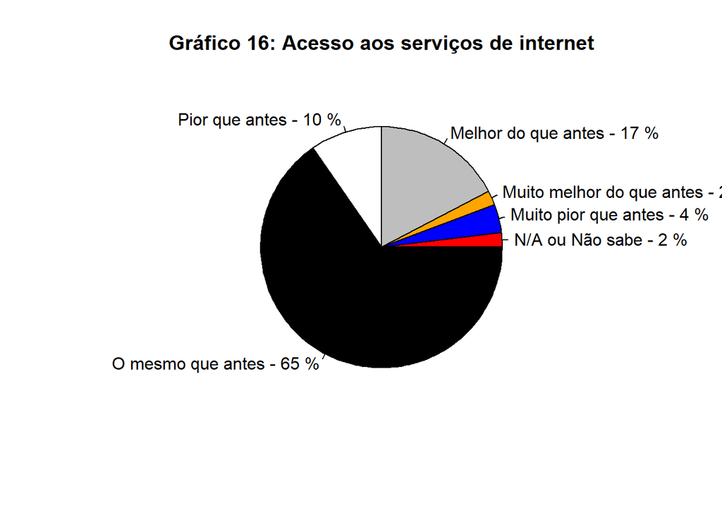

No que concerne à mudança para o ensino virtual remoto e a mudança na forma de aprendizado, os dados do Gráfico 17 mostram que 38% dos participantes considera que não houve queda no seu desempenho escolar e 27% consideram que o seu desempenho acadêmico aumentou no ensino remoto, se comparado ao presencial.

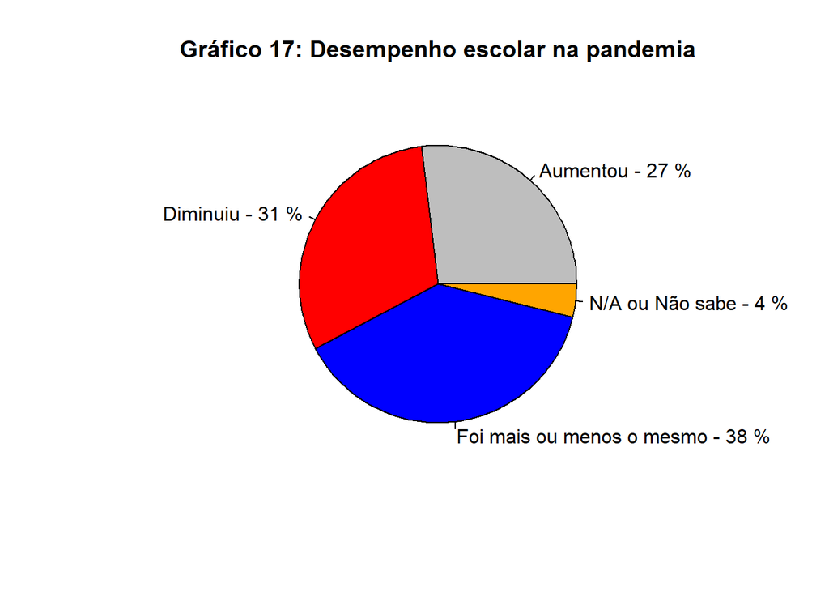

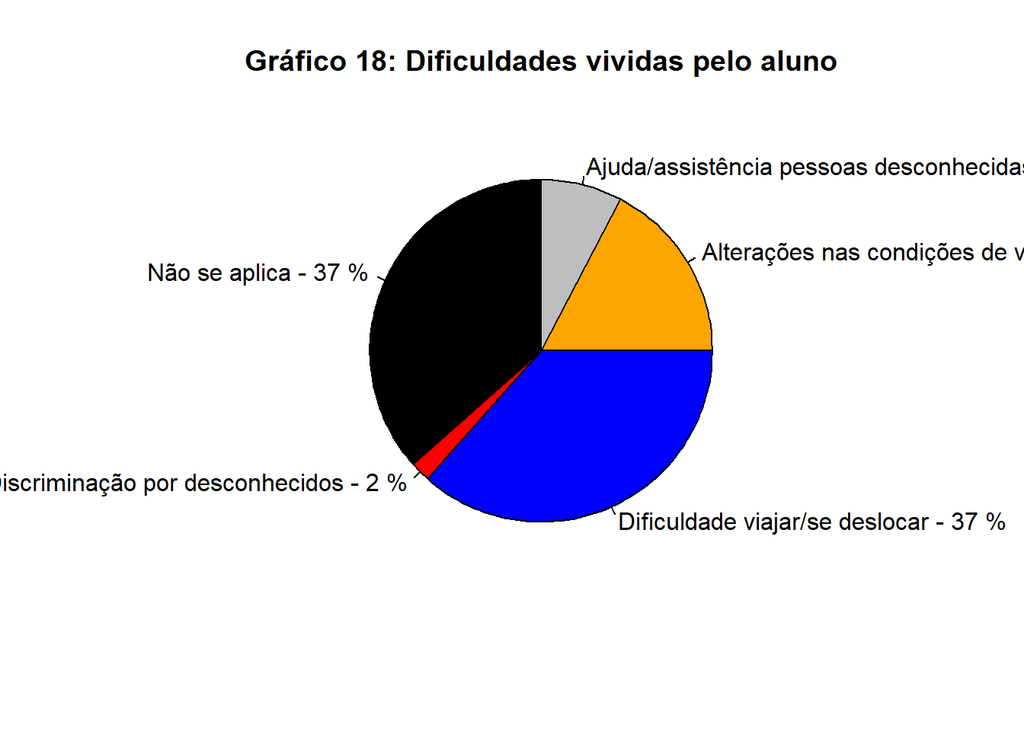

Além das dificuldades apontadas nos dados do Gráfico 18, dada as restrições sociais a vida financeira dos discentes também foi afetada de maneira importante. Os dados compilados no Gráfico 19 ilustram a opiniãodos alunos em relação aos seus gastos durante o a pandemia onde 40% alegam que as despesas não sofreram alteração, 33% que houve incremento nas suas despesas e 27% tiveram redução.

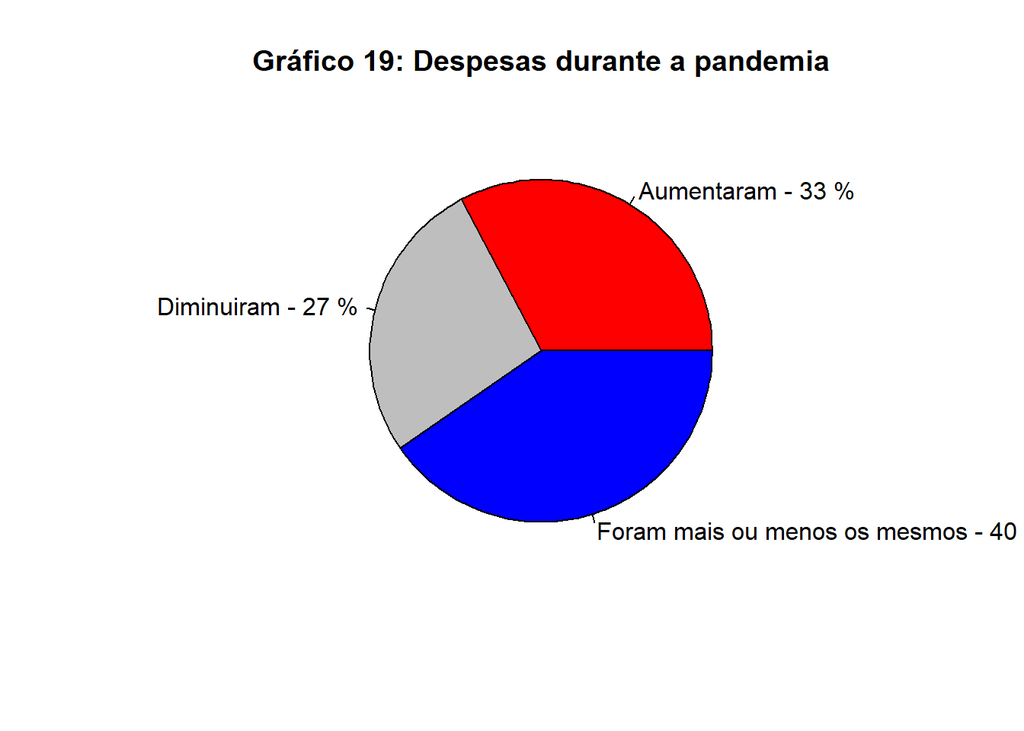

Apesar da maioria dos entrevistados não terem sofrido com o aumento de despesas, já com relação ao seu poder de compra observamos no Gráfico 20 que 48% observaram uma queda no seu poder de compra e 44% consideram que sua renda continuou mais ou menos a mesma.

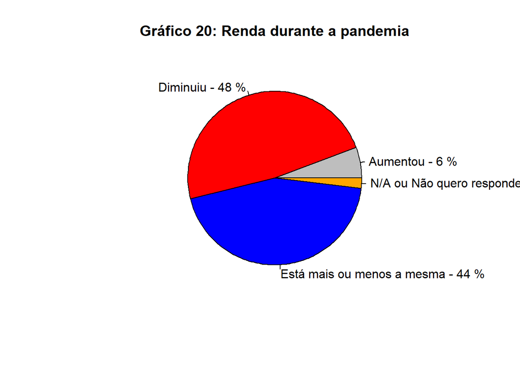

Como pode ser observado no Gráfico 20, apenas 6% tiveram aumento nos rendimentos e 2% não quiseram e/ou souberam opinar.

Ainda que muitas universidades públicas ofereçam auxílio financeiro para que estudantes possam morar no campus (ou próximo de) para estudarem, de acordo com os dados do Gráfico 21 observa-se que durante o período de pandemia 85% dos entrevistados não tiveram nenhum respaldo por parte da instituição educacional ou de outra organização.

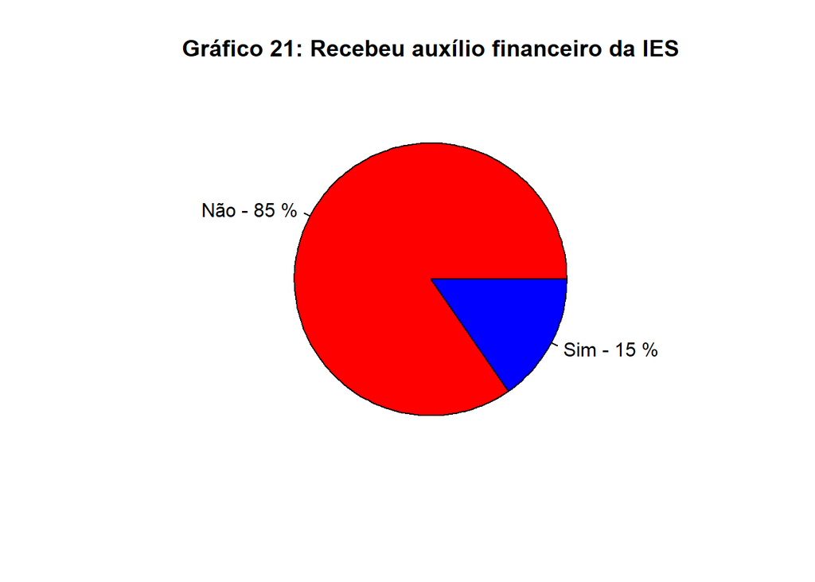

Quanto ao nível de endividamento durante a pandemia, os estudantes afirmaram que 69% não tiveram alteração nos seus débitos, como é possível observar no Gráfico 22.

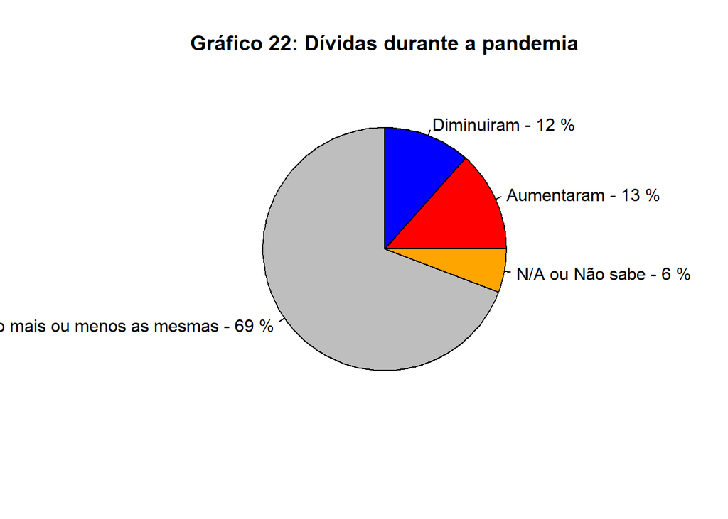

Já 13% afirmaram ter aumentado o seu nível de endividamento, 12% uma diminuição, e 6% não souberam informar, como ilustram os dados no Gráfico 22. Pensando em um cenário “pós-pandêmico” (após o pico da pandemia 2020/2022), foi solicitado aos participantes manifestar quais gastos realizados por cada estudante que cresceram em diversos segmentos. Nesta questão de resposta múltipla os respondentes poderiam indicar mais de um segmento concomitantemente. Os dados compilados das respostas estão ilustrados no Gráfico 23.

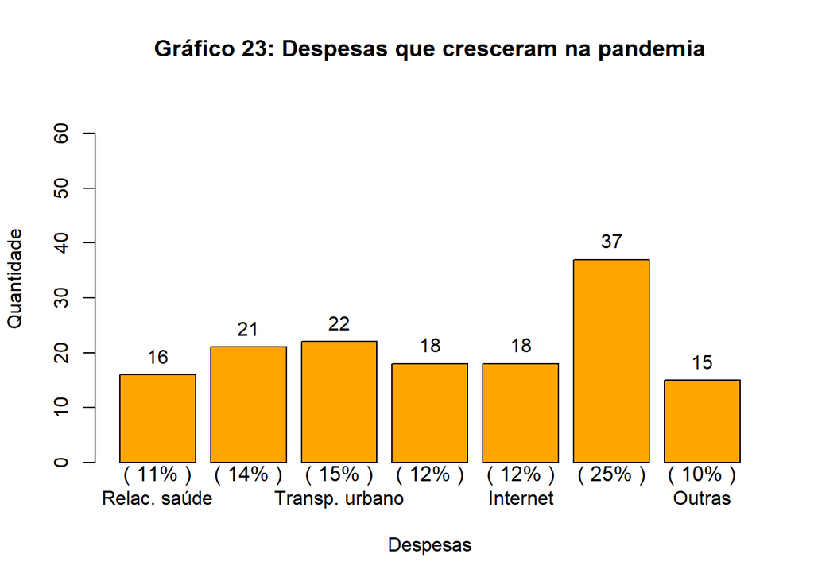

## Análise qualitativa

Questões com gráfico de chuvas de palavras! Como agregar e analisá-las ?

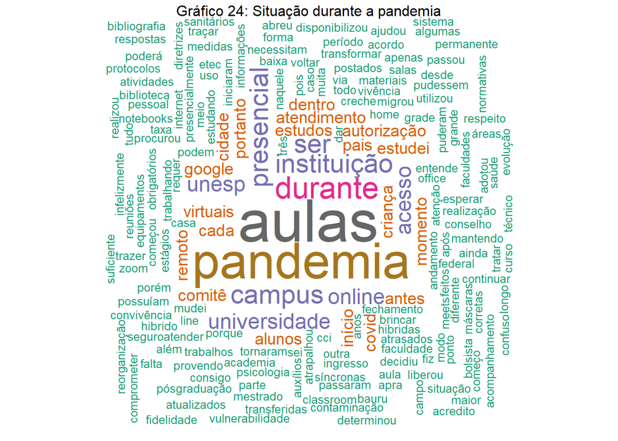

```
## [1] "Principais ocorrências de palavras em situação durante a pandemia"
```

```
## [1] "aulas = 11"
## [1] "pandemia = 9"
## [1] "durante = 5"
## [1] "instituição = 4"
## [1] "ser = 4"
## [1] "presencial = 4"
## [1] "campus = 4"
## [1] "unesp = 3"
## [1] "online = 3"
## [1] "universidade = 3"
## [1] "acesso = 3"
```

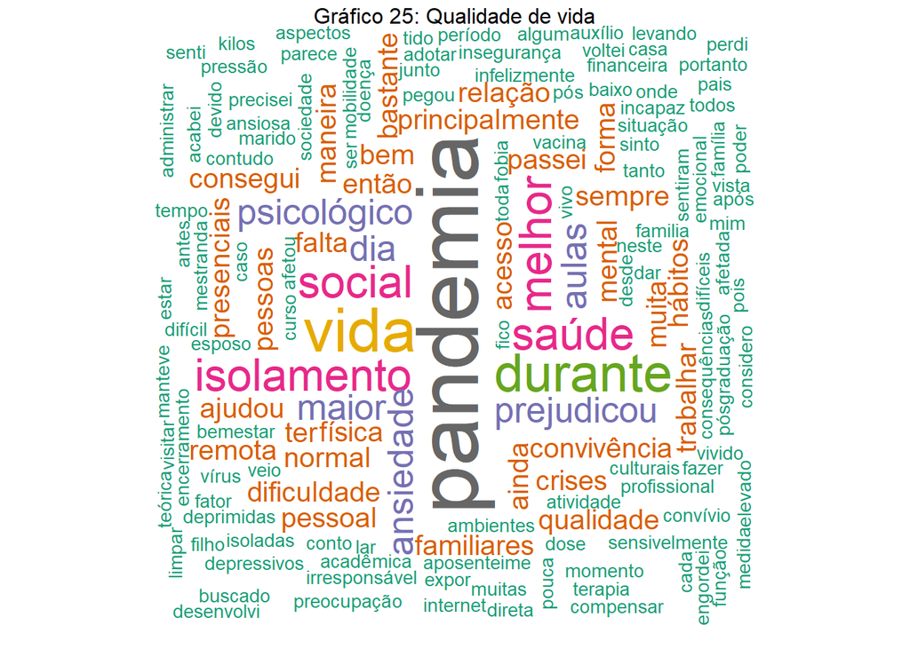

```
## [1] "Principais ocorrências de palavras em qualidade de vida"
```

```
## [1] "pandemia = 9"
## [1] "vida = 6"
## [1] "durante = 5"
## [1] "saúde = 4"
## [1] "social = 4"
## [1] "isolamento = 4"
## [1] "melhor = 4"
## [1] "prejudicou = 3"
## [1] "psicológico = 3"
## [1] "ansiedade = 3"
## [1] "aulas = 3"
## [1] "dia = 3"
## [1] "maior = 3"
```

### ———————————————————–

### Gráficos opinando com relação às ações tomadas pela IES

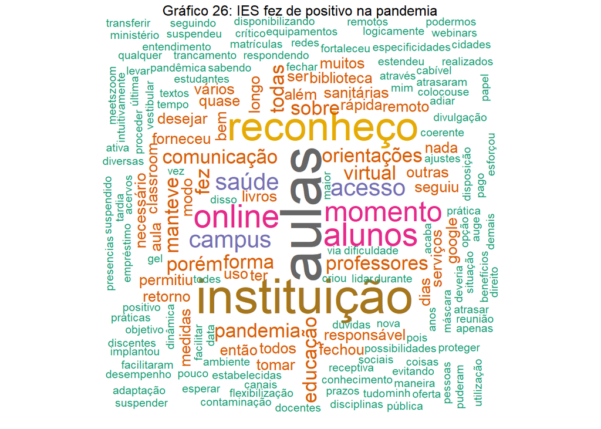

```
## [1] "Principais ocorrências de palavras do que a IES fez de positivo na pandemia"
```

```
## [1] "aulas = 12"
## [1] "instituição = 10"
## [1] "reconheço = 8"
## [1] "alunos = 6"
## [1] "online = 6"
## [1] "momento = 5"
## [1] "acesso = 4"
## [1] "saúde = 4"
## [1] "campus = 4"
## [1] "forma = 3"
## [1] "professores = 3"
## [1] "virtual = 3"
## [1] "orientações = 3"
## [1] "comunicação = 3"
## [1] "manteve = 3"
## [1] "sobre = 3"
## [1] "porém = 3"
## [1] "pandemia = 3"
## [1] "fez = 3"
## [1] "educação = 3"
## [1] "todas = 3"
```

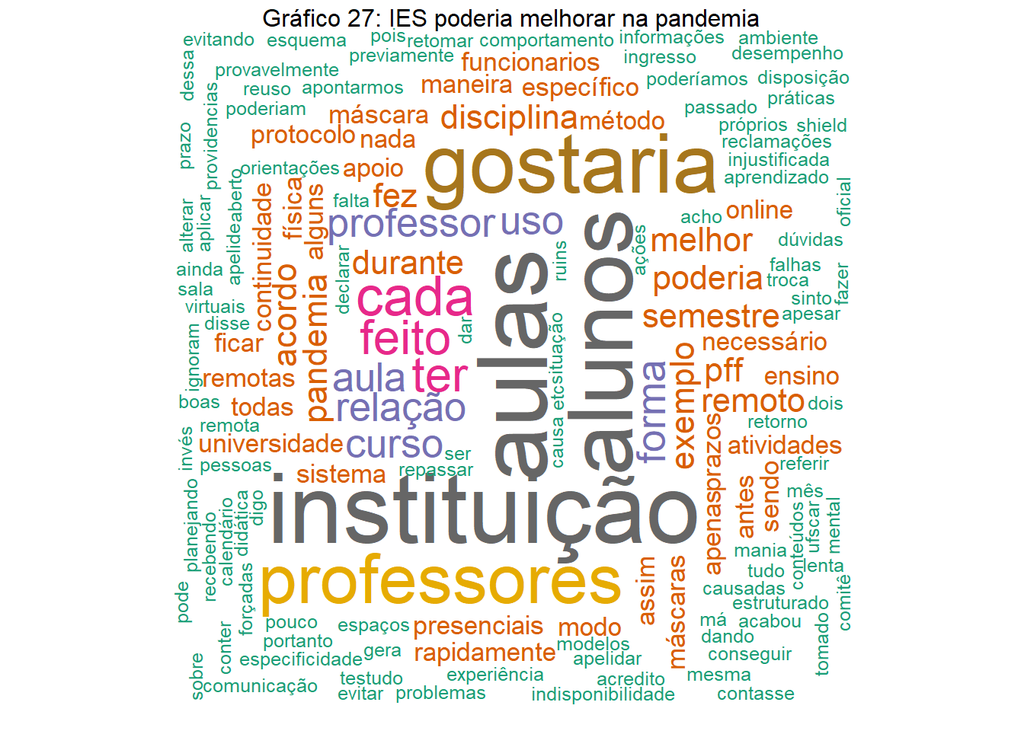

```
## [1] "Principais ocorrências de palavras do que a IES poderia melhorar na pandemia"
```

```
## [1] "aulas = 12"
## [1] "instituição = 12"
## [1] "alunos = 11"
## [1] "gostaria = 10"
## [1] "professores = 8"
## [1] "cada = 6"
## [1] "feito = 5"
## [1] "ter = 5"
## [1] "relação = 4"
## [1] "curso = 4"
## [1] "professor = 4"
## [1] "uso = 4"
## [1] "aula = 4"
## [1] "forma = 4"
## [1] "durante = 3"
## [1] "exemplo = 3"
## [1] "pandemia = 3"
## [1] "semestre = 3"
## [1] "poderia = 3"
## [1] "remoto = 3"
## [1] "acordo = 3"
## [1] "melhor = 3"
## [1] "disciplina = 3"
## [1] "fez = 3"
## [1] "pff = 3"
```

[figure not shown]

```
## [1] "Principais ocorrências de palavras do que a IES poderia melhora ajudar na pandemia"
```

```
## [1] "instituição = 7"
## [1] "ajudaria = 6"
## [1] "além = 6"
## [1] "alunos = 6"
## [1] "aulas = 5"
## [1] "feito = 5"
## [1] "presencial = 4"
## [1] "pandemia = 3"
## [1] "sei = 3"
## [1] "online = 3"
## [1] "situação = 3"
```

## ——————————————————

## Gráficos avaliando a situação psicológica dos alunos

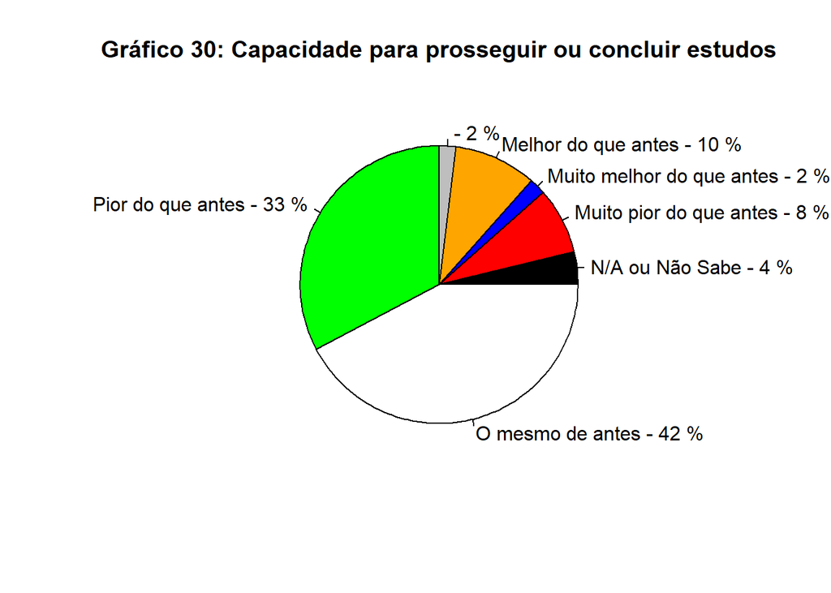

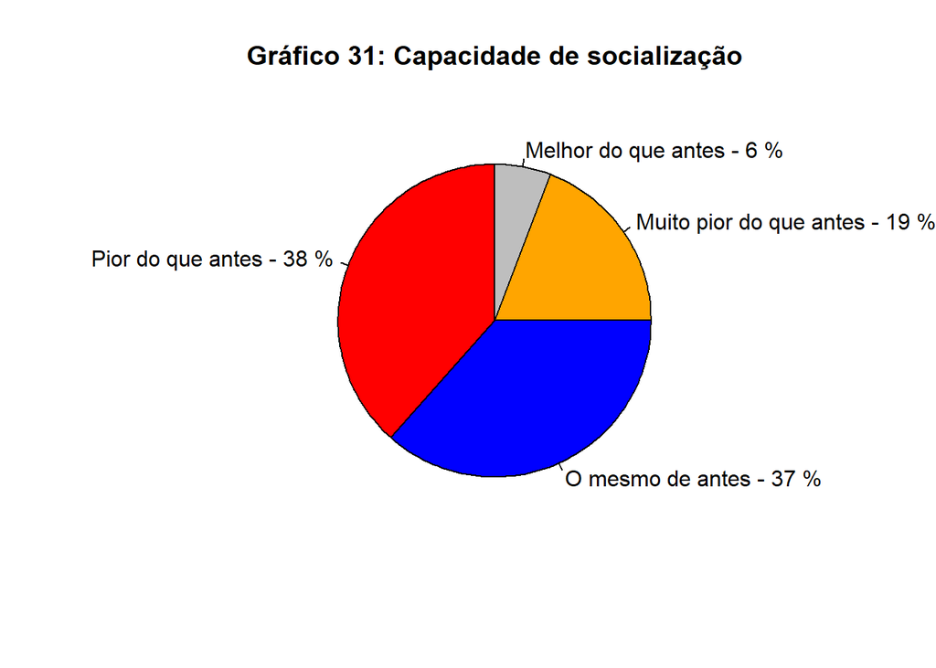

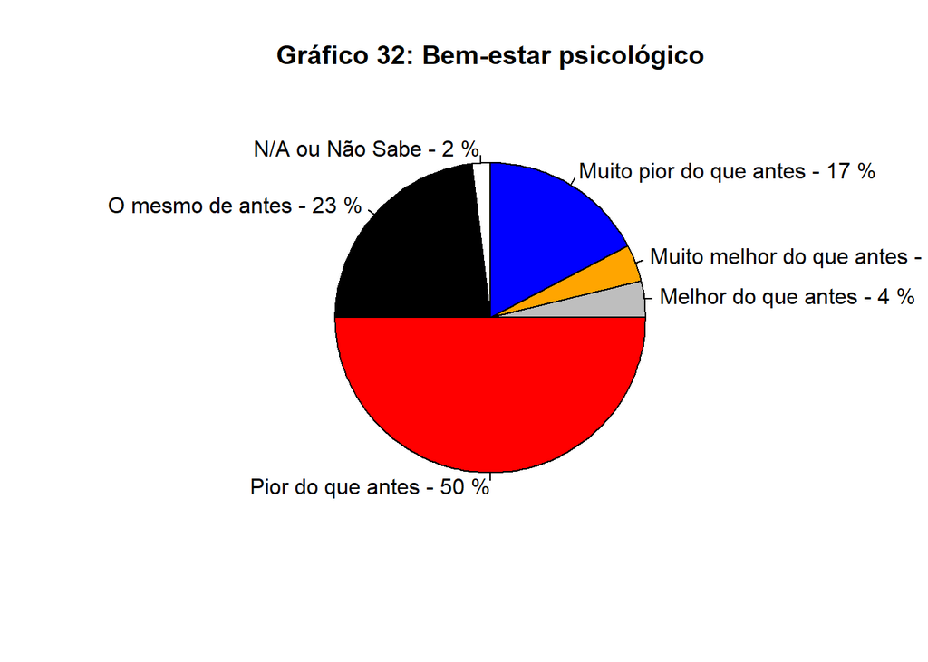

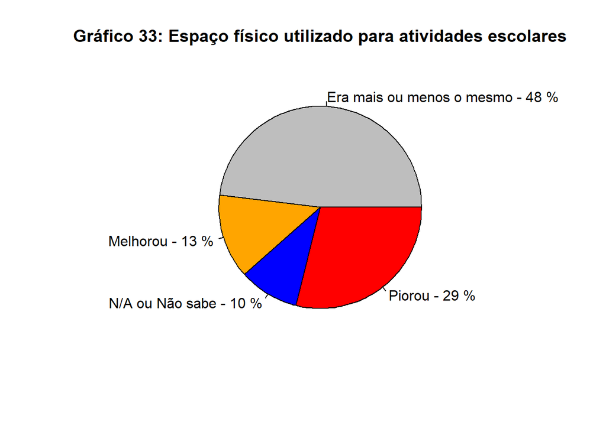